# Risk Factor Analysis

## Outcome Variable

**Outcome Variable:** y_rate_lencm

## Predictor Variables

**Intervention Variable:** mbmi

**Adjustment Set:**

unadjusted

## Stratifying Variables

The analysis was stratified on these variable(s):

- diffcat
- studyid
- country

## Data Summary

| diffcat | studyid | country | mbmi | n_cell | n |
| --- | --- | --- | --- | --- | --- |
| 0-3 months | ki0047075b-MAL-ED | BANGLADESH | [18.5-25) | 157 | 244 |
| 0-3 months | ki0047075b-MAL-ED | BANGLADESH | <18.5 | 32 | 244 |
| 0-3 months | ki0047075b-MAL-ED | BANGLADESH | [25-30) | 49 | 244 |
| 0-3 months | ki0047075b-MAL-ED | BANGLADESH | >=30 | 6 | 244 |
| 3-6 months | ki0047075b-MAL-ED | BANGLADESH | [18.5-25) | 147 | 231 |
| 3-6 months | ki0047075b-MAL-ED | BANGLADESH | <18.5 | 30 | 231 |
| 3-6 months | ki0047075b-MAL-ED | BANGLADESH | [25-30) | 48 | 231 |
| 3-6 months | ki0047075b-MAL-ED | BANGLADESH | >=30 | 6 | 231 |
| 6-12 months | ki0047075b-MAL-ED | BANGLADESH | [18.5-25) | 142 | 220 |
| 6-12 months | ki0047075b-MAL-ED | BANGLADESH | <18.5 | 26 | 220 |
| 6-12 months | ki0047075b-MAL-ED | BANGLADESH | [25-30) | 47 | 220 |
| 6-12 months | ki0047075b-MAL-ED | BANGLADESH | >=30 | 5 | 220 |
| 12-24 months | ki0047075b-MAL-ED | BANGLADESH | [18.5-25) | 131 | 206 |
| 12-24 months | ki0047075b-MAL-ED | BANGLADESH | <18.5 | 27 | 206 |
| 12-24 months | ki0047075b-MAL-ED | BANGLADESH | [25-30) | 44 | 206 |
| 12-24 months | ki0047075b-MAL-ED | BANGLADESH | >=30 | 4 | 206 |
| 12-24 months | ki1000110-WASH-Bangladesh | BANGLADESH | [18.5-25) | 21 | 38 |
| 12-24 months | ki1000110-WASH-Bangladesh | BANGLADESH | <18.5 | 17 | 38 |
| 0-3 months | ki1017093-NIH-Birth | BANGLADESH | [18.5-25) | 400 | 566 |
| 0-3 months | ki1017093-NIH-Birth | BANGLADESH | <18.5 | 94 | 566 |
| 0-3 months | ki1017093-NIH-Birth | BANGLADESH | [25-30) | 58 | 566 |
| 0-3 months | ki1017093-NIH-Birth | BANGLADESH | >=30 | 14 | 566 |
| 3-6 months | ki1017093-NIH-Birth | BANGLADESH | [18.5-25) | 363 | 523 |
| 3-6 months | ki1017093-NIH-Birth | BANGLADESH | <18.5 | 91 | 523 |
| 3-6 months | ki1017093-NIH-Birth | BANGLADESH | [25-30) | 55 | 523 |
| 3-6 months | ki1017093-NIH-Birth | BANGLADESH | >=30 | 14 | 523 |
| 6-12 months | ki1017093-NIH-Birth | BANGLADESH | [18.5-25) | 331 | 482 |
| 6-12 months | ki1017093-NIH-Birth | BANGLADESH | <18.5 | 89 | 482 |
| 6-12 months | ki1017093-NIH-Birth | BANGLADESH | [25-30) | 53 | 482 |
| 6-12 months | ki1017093-NIH-Birth | BANGLADESH | >=30 | 9 | 482 |

[output cut: 201 more lines]

The following strata were considered:

- diffcat: 0-3 months, studyid: ki0047075b-MAL-ED, country: BANGLADESH
- diffcat: 0-3 months, studyid: ki0047075b-MAL-ED, country: BRAZIL
- diffcat: 0-3 months, studyid: ki0047075b-MAL-ED, country: INDIA
- diffcat: 0-3 months, studyid: ki0047075b-MAL-ED, country: NEPAL
- diffcat: 0-3 months, studyid: ki0047075b-MAL-ED, country: PERU
- diffcat: 0-3 months, studyid: ki0047075b-MAL-ED, country: SOUTH AFRICA
- diffcat: 0-3 months, studyid: ki0047075b-MAL-ED, country: TANZANIA, UNITED REPUBLIC OF
- diffcat: 0-3 months, studyid: ki1000304b-SAS-CompFeed, country: INDIA
- diffcat: 0-3 months, studyid: ki1017093-NIH-Birth, country: BANGLADESH
- diffcat: 0-3 months, studyid: ki1017093b-PROVIDE, country: BANGLADESH
- diffcat: 0-3 months, studyid: ki1017093c-NIH-Crypto, country: BANGLADESH
- diffcat: 0-3 months, studyid: ki1119695-PROBIT, country: BELARUS
- diffcat: 0-3 months, studyid: ki1126311-ZVITAMBO, country: ZIMBABWE
- diffcat: 12-24 months, studyid: ki0047075b-MAL-ED, country: BANGLADESH
- diffcat: 12-24 months, studyid: ki0047075b-MAL-ED, country: BRAZIL
- diffcat: 12-24 months, studyid: ki0047075b-MAL-ED, country: INDIA
- diffcat: 12-24 months, studyid: ki0047075b-MAL-ED, country: NEPAL
- diffcat: 12-24 months, studyid: ki0047075b-MAL-ED, country: PERU
- diffcat: 12-24 months, studyid: ki0047075b-MAL-ED, country: SOUTH AFRICA
- diffcat: 12-24 months, studyid: ki0047075b-MAL-ED, country: TANZANIA, UNITED REPUBLIC OF
- diffcat: 12-24 months, studyid: ki1000110-WASH-Bangladesh, country: BANGLADESH
- diffcat: 12-24 months, studyid: ki1017093-NIH-Birth, country: BANGLADESH
- diffcat: 12-24 months, studyid: ki1017093b-PROVIDE, country: BANGLADESH
- diffcat: 12-24 months, studyid: ki1017093c-NIH-Crypto, country: BANGLADESH
- diffcat: 12-24 months, studyid: ki1066203-TanzaniaChild2, country: TANZANIA, UNITED REPUBLIC OF
- diffcat: 12-24 months, studyid: ki1112895-Burkina Faso Zn, country: BURKINA FASO
- diffcat: 12-24 months, studyid: ki1119695-PROBIT, country: BELARUS
- diffcat: 12-24 months, studyid: ki1126311-ZVITAMBO, country: ZIMBABWE
- diffcat: 12-24 months, studyid: ki1148112-iLiNS-DOSE, country: MALAWI
- diffcat: 12-24 months, studyid: ki1148112-LCNI-5, country: MALAWI
- diffcat: 3-6 months, studyid: ki0047075b-MAL-ED, country: BANGLADESH
- diffcat: 3-6 months, studyid: ki0047075b-MAL-ED, country: BRAZIL
- diffcat: 3-6 months, studyid: ki0047075b-MAL-ED, country: INDIA
- diffcat: 3-6 months, studyid: ki0047075b-MAL-ED, country: NEPAL
- diffcat: 3-6 months, studyid: ki0047075b-MAL-ED, country: PERU
- diffcat: 3-6 months, studyid: ki0047075b-MAL-ED, country: SOUTH AFRICA
- diffcat: 3-6 months, studyid: ki0047075b-MAL-ED, country: TANZANIA, UNITED REPUBLIC OF
- diffcat: 3-6 months, studyid: ki1000304b-SAS-CompFeed, country: INDIA
- diffcat: 3-6 months, studyid: ki1017093-NIH-Birth, country: BANGLADESH
- diffcat: 3-6 months, studyid: ki1017093b-PROVIDE, country: BANGLADESH
- diffcat: 3-6 months, studyid: ki1017093c-NIH-Crypto, country: BANGLADESH
- diffcat: 3-6 months, studyid: ki1066203-TanzaniaChild2, country: TANZANIA, UNITED REPUBLIC OF
- diffcat: 3-6 months, studyid: ki1119695-PROBIT, country: BELARUS
- diffcat: 3-6 months, studyid: ki1126311-ZVITAMBO, country: ZIMBABWE
- diffcat: 6-12 months, studyid: ki0047075b-MAL-ED, country: BANGLADESH
- diffcat: 6-12 months, studyid: ki0047075b-MAL-ED, country: BRAZIL
- diffcat: 6-12 months, studyid: ki0047075b-MAL-ED, country: INDIA
- diffcat: 6-12 months, studyid: ki0047075b-MAL-ED, country: NEPAL
- diffcat: 6-12 months, studyid: ki0047075b-MAL-ED, country: PERU
- diffcat: 6-12 months, studyid: ki0047075b-MAL-ED, country: SOUTH AFRICA
- diffcat: 6-12 months, studyid: ki0047075b-MAL-ED, country: TANZANIA, UNITED REPUBLIC OF
- diffcat: 6-12 months, studyid: ki1000304b-SAS-CompFeed, country: INDIA
- diffcat: 6-12 months, studyid: ki1017093-NIH-Birth, country: BANGLADESH
- diffcat: 6-12 months, studyid: ki1017093b-PROVIDE, country: BANGLADESH
- diffcat: 6-12 months, studyid: ki1017093c-NIH-Crypto, country: BANGLADESH
- diffcat: 6-12 months, studyid: ki1066203-TanzaniaChild2, country: TANZANIA, UNITED REPUBLIC OF
- diffcat: 6-12 months, studyid: ki1119695-PROBIT, country: BELARUS
- diffcat: 6-12 months, studyid: ki1126311-ZVITAMBO, country: ZIMBABWE
- diffcat: 6-12 months, studyid: ki1148112-iLiNS-DOSE, country: MALAWI
- diffcat: 6-12 months, studyid: ki1148112-iLiNS-DYAD-M, country: MALAWI
- diffcat: 6-12 months, studyid: ki1148112-LCNI-5, country: MALAWI

### Dropped Strata

Some strata were dropped due to rare outcomes:

- diffcat: 12-24 months, studyid: ki0047075b-MAL-ED, country: BANGLADESH
- diffcat: 12-24 months, studyid: ki1112895-Burkina Faso Zn, country: BURKINA FASO
- diffcat: 0-3 months, studyid: ki1000304b-SAS-CompFeed, country: INDIA
- diffcat: 6-12 months, studyid: ki1148112-LCNI-5, country: MALAWI
- diffcat: 12-24 months, studyid: ki1148112-LCNI-5, country: MALAWI
- diffcat: 6-12 months, studyid: ki1148112-iLiNS-DYAD-M, country: MALAWI
- diffcat: 6-12 months, studyid: ki0047075b-MAL-ED, country: PERU
- diffcat: 12-24 months, studyid: ki0047075b-MAL-ED, country: PERU
- diffcat: 0-3 months, studyid: ki0047075b-MAL-ED, country: SOUTH AFRICA
- diffcat: 12-24 months, studyid: ki1066203-TanzaniaChild2, country: TANZANIA, UNITED REPUBLIC OF

## Methods Detail

We’re interested in the causal parameters $E[Y_a]$ for all values of $a \in \mathcal{A}$. These parameters represent the mean outcome if, possibly contrary to fact, we intervened to set all units to have $A=a$. Under the randomization and positivity assumptions, these are identified by the statistical parameters $\psi_a=E_W[E_{Y|A,W}(Y|A=a,W)]$. In addition, we’re interested in the mean of $Y$, $E[Y]$ under no intervention (the observed mean). We will estimate these parameters by using SuperLearner to fit the relevant likelihood factors – $E_{Y|A,W}(Y|A=a,W)$ and $p(A=a|W)$, and then updating our likelihood fit using a joint TMLE.

For unadjusted analyses ($W=\{\}$), initial likelihoods were estimated using Lrnr_glm to estimate the simple $E(Y|A)$ and Lrnr_mean to estimate $p(A)$. For adjusted analyses, a small library containing Lrnr_glmnet, Lrnr_xgboost, and Lrnr_mean was used.

Having estimated these parameters, we will then use the delta method to estimate relative risks and attributable risks relative to a prespecified baseline level of $A$.

# Results Detail

## Results Plots

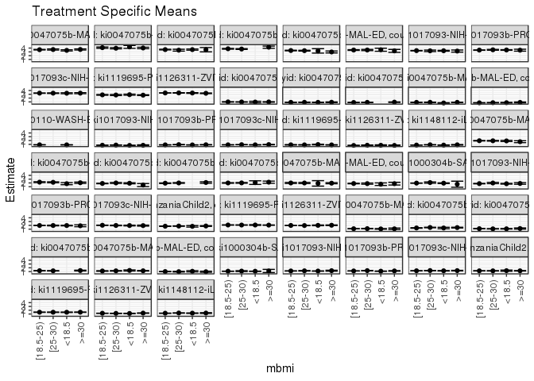

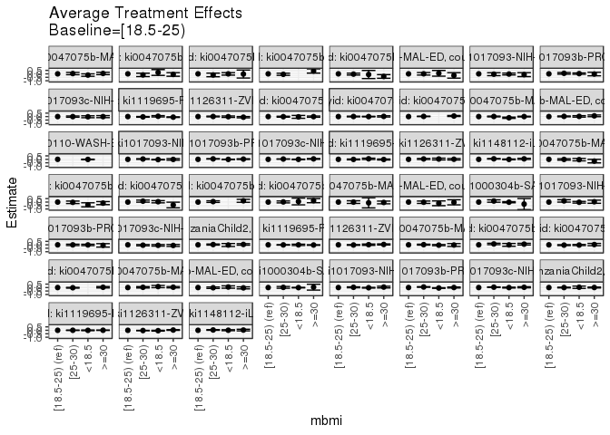

## Results Table

### Parameter: TSM

| diffcat | studyid | country | intervention_level | baseline_level | estimate | ci_lower | ci_upper |
| --- | --- | --- | --- | --- | --- | --- | --- |
| 0-3 months | ki0047075b-MAL-ED | BANGLADESH | [18.5-25) | NA | 3.5768962 | 3.4979412 | 3.6558513 |
| 0-3 months | ki0047075b-MAL-ED | BANGLADESH | <18.5 | NA | 3.3993019 | 3.2449736 | 3.5536303 |
| 0-3 months | ki0047075b-MAL-ED | BANGLADESH | [25-30) | NA | 3.6189164 | 3.4718960 | 3.7659368 |
| 0-3 months | ki0047075b-MAL-ED | BANGLADESH | >=30 | NA | 3.6338728 | 3.4849865 | 3.7827592 |
| 0-3 months | ki0047075b-MAL-ED | BRAZIL | [18.5-25) | NA | 4.1155921 | 3.9387030 | 4.2924812 |
| 0-3 months | ki0047075b-MAL-ED | BRAZIL | <18.5 | NA | 4.3101110 | 3.9286057 | 4.6916163 |
| 0-3 months | ki0047075b-MAL-ED | BRAZIL | [25-30) | NA | 3.9622420 | 3.7953228 | 4.1291612 |
| 0-3 months | ki0047075b-MAL-ED | BRAZIL | >=30 | NA | 4.0292604 | 3.8363942 | 4.2221267 |
| 0-3 months | ki0047075b-MAL-ED | INDIA | [18.5-25) | NA | 3.6038658 | 3.5128676 | 3.6948640 |
| 0-3 months | ki0047075b-MAL-ED | INDIA | <18.5 | NA | 3.5992026 | 3.4459956 | 3.7524096 |
| 0-3 months | ki0047075b-MAL-ED | INDIA | [25-30) | NA | 3.4462630 | 3.2031164 | 3.6894096 |
| 0-3 months | ki0047075b-MAL-ED | INDIA | >=30 | NA | 3.5753480 | 3.0055253 | 4.1451707 |
| 0-3 months | ki0047075b-MAL-ED | NEPAL | [18.5-25) | NA | 3.8188853 | 3.7158680 | 3.9219025 |
| 0-3 months | ki0047075b-MAL-ED | NEPAL | [25-30) | NA | 3.7500536 | 3.6378599 | 3.8622473 |
| 0-3 months | ki0047075b-MAL-ED | NEPAL | >=30 | NA | 4.2324316 | 3.9444217 | 4.5204415 |
| 0-3 months | ki0047075b-MAL-ED | PERU | [18.5-25) | NA | 3.3564932 | 3.2755173 | 3.4374691 |
| 0-3 months | ki0047075b-MAL-ED | PERU | <18.5 | NA | 3.2603545 | 2.6770107 | 3.8436982 |
| 0-3 months | ki0047075b-MAL-ED | PERU | [25-30) | NA | 3.3161426 | 3.2095879 | 3.4226973 |
| 0-3 months | ki0047075b-MAL-ED | PERU | >=30 | NA | 2.9798196 | 2.7264035 | 3.2332356 |
| 0-3 months | ki0047075b-MAL-ED | TANZANIA, UNITED REPUBLIC OF | [18.5-25) | NA | 3.4850357 | 3.3930209 | 3.5770505 |
| 0-3 months | ki0047075b-MAL-ED | TANZANIA, UNITED REPUBLIC OF | <18.5 | NA | 3.5645980 | 3.1622003 | 3.9669958 |
| 0-3 months | ki0047075b-MAL-ED | TANZANIA, UNITED REPUBLIC OF | [25-30) | NA | 3.4912891 | 3.3320630 | 3.6505151 |
| 0-3 months | ki0047075b-MAL-ED | TANZANIA, UNITED REPUBLIC OF | >=30 | NA | 3.2604808 | 2.8755711 | 3.6453906 |
| 0-3 months | ki1017093-NIH-Birth | BANGLADESH | [18.5-25) | NA | 3.3257154 | 3.2599165 | 3.3915144 |
| 0-3 months | ki1017093-NIH-Birth | BANGLADESH | <18.5 | NA | 3.2958636 | 3.1809863 | 3.4107409 |
| 0-3 months | ki1017093-NIH-Birth | BANGLADESH | [25-30) | NA | 3.2763496 | 3.0752303 | 3.4774689 |
| 0-3 months | ki1017093-NIH-Birth | BANGLADESH | >=30 | NA | 3.2135837 | 2.9343722 | 3.4927953 |
| 0-3 months | ki1017093b-PROVIDE | BANGLADESH | [18.5-25) | NA | 3.4674479 | 3.4184862 | 3.5164096 |
| 0-3 months | ki1017093b-PROVIDE | BANGLADESH | <18.5 | NA | 3.4994585 | 3.4156159 | 3.5833011 |
| 0-3 months | ki1017093b-PROVIDE | BANGLADESH | [25-30) | NA | 3.5442920 | 3.4365126 | 3.6520714 |

[output cut: 168 more lines]

### Parameter: E(Y)

| diffcat | studyid | country | intervention_level | baseline_level | estimate | ci_lower | ci_upper |
| --- | --- | --- | --- | --- | --- | --- | --- |
| 0-3 months | ki0047075b-MAL-ED | BANGLADESH | NA | NA | 3.5634447 | 3.5006347 | 3.6262547 |
| 0-3 months | ki0047075b-MAL-ED | BRAZIL | NA | NA | 4.0509714 | 3.9492443 | 4.1526985 |
| 0-3 months | ki0047075b-MAL-ED | INDIA | NA | NA | 3.5764512 | 3.4977133 | 3.6551891 |
| 0-3 months | ki0047075b-MAL-ED | NEPAL | NA | NA | 3.8204935 | 3.7444190 | 3.8965681 |
| 0-3 months | ki0047075b-MAL-ED | PERU | NA | NA | 3.3169985 | 3.2535876 | 3.3804093 |
| 0-3 months | ki0047075b-MAL-ED | TANZANIA, UNITED REPUBLIC OF | NA | NA | 3.4816904 | 3.4044928 | 3.5588880 |
| 0-3 months | ki1017093-NIH-Birth | BANGLADESH | NA | NA | 3.3129255 | 3.2581305 | 3.3677204 |
| 0-3 months | ki1017093b-PROVIDE | BANGLADESH | NA | NA | 3.4842409 | 3.4451170 | 3.5233649 |
| 0-3 months | ki1017093c-NIH-Crypto | BANGLADESH | NA | NA | 3.3028656 | 3.2646714 | 3.3410598 |
| 0-3 months | ki1119695-PROBIT | BELARUS | NA | NA | 2.8377102 | 2.7235014 | 2.9519189 |
| 0-3 months | ki1126311-ZVITAMBO | ZIMBABWE | NA | NA | 3.3523868 | 3.3301424 | 3.3746313 |
| 3-6 months | ki0047075b-MAL-ED | BANGLADESH | NA | NA | 1.9280462 | 1.8787523 | 1.9773401 |
| 3-6 months | ki0047075b-MAL-ED | BRAZIL | NA | NA | 2.1465654 | 2.0670402 | 2.2260907 |
| 3-6 months | ki0047075b-MAL-ED | INDIA | NA | NA | 1.8804733 | 1.8192508 | 1.9416958 |
| 3-6 months | ki0047075b-MAL-ED | NEPAL | NA | NA | 1.9680995 | 1.9120346 | 2.0241643 |
| 3-6 months | ki0047075b-MAL-ED | PERU | NA | NA | 2.0179168 | 1.9519428 | 2.0838909 |
| 3-6 months | ki0047075b-MAL-ED | SOUTH AFRICA | NA | NA | 1.9721457 | 1.8908533 | 2.0534381 |
| 3-6 months | ki0047075b-MAL-ED | TANZANIA, UNITED REPUBLIC OF | NA | NA | 1.8300902 | 1.7622436 | 1.8979368 |
| 3-6 months | ki1000304b-SAS-CompFeed | INDIA | NA | NA | 1.9552312 | 1.9134079 | 1.9970545 |
| 3-6 months | ki1017093-NIH-Birth | BANGLADESH | NA | NA | 1.8326915 | 1.7846731 | 1.8807099 |
| 3-6 months | ki1017093b-PROVIDE | BANGLADESH | NA | NA | 1.9654067 | 1.9302800 | 2.0005334 |
| 3-6 months | ki1017093c-NIH-Crypto | BANGLADESH | NA | NA | 2.0057973 | 1.9693775 | 2.0422170 |
| 3-6 months | ki1066203-TanzaniaChild2 | TANZANIA, UNITED REPUBLIC OF | NA | NA | 1.7982528 | 1.7619937 | 1.8345119 |
| 3-6 months | ki1119695-PROBIT | BELARUS | NA | NA | 2.0907239 | 2.0499674 | 2.1314804 |
| 3-6 months | ki1126311-ZVITAMBO | ZIMBABWE | NA | NA | 1.9804622 | 1.9597476 | 2.0011769 |
| 6-12 months | ki0047075b-MAL-ED | BANGLADESH | NA | NA | 1.1143928 | 1.0896103 | 1.1391753 |
| 6-12 months | ki0047075b-MAL-ED | BRAZIL | NA | NA | 1.3821617 | 1.3363222 | 1.4280012 |
| 6-12 months | ki0047075b-MAL-ED | INDIA | NA | NA | 1.1193380 | 1.0909904 | 1.1476855 |
| 6-12 months | ki0047075b-MAL-ED | NEPAL | NA | NA | 1.2224454 | 1.1966480 | 1.2482429 |
| 6-12 months | ki0047075b-MAL-ED | SOUTH AFRICA | NA | NA | 1.1869461 | 1.1457857 | 1.2281065 |
| 6-12 months | ki0047075b-MAL-ED | TANZANIA, UNITED REPUBLIC OF | NA | NA | 1.0019524 | 0.9648566 | 1.0390481 |
| 6-12 months | ki1000304b-SAS-CompFeed | INDIA | NA | NA | 1.1017930 | 1.0897842 | 1.1138017 |
| 6-12 months | ki1017093-NIH-Birth | BANGLADESH | NA | NA | 1.1679344 | 1.1454934 | 1.1903754 |
| 6-12 months | ki1017093b-PROVIDE | BANGLADESH | NA | NA | 1.1731762 | 1.1558671 | 1.1904853 |
| 6-12 months | ki1017093c-NIH-Crypto | BANGLADESH | NA | NA | 1.2281313 | 1.2106849 | 1.2455776 |
| 6-12 months | ki1066203-TanzaniaChild2 | TANZANIA, UNITED REPUBLIC OF | NA | NA | 1.1971906 | 1.1754499 | 1.2189312 |
| 6-12 months | ki1119695-PROBIT | BELARUS | NA | NA | 1.4723651 | 1.4336785 | 1.5110518 |
| 6-12 months | ki1126311-ZVITAMBO | ZIMBABWE | NA | NA | 1.1979900 | 1.1865747 | 1.2094054 |
| 6-12 months | ki1148112-iLiNS-DOSE | MALAWI | NA | NA | 1.2232165 | 1.2063248 | 1.2401083 |
| 12-24 months | ki0047075b-MAL-ED | BRAZIL | NA | NA | 0.9836574 | 0.9529821 | 1.0143327 |
| 12-24 months | ki0047075b-MAL-ED | INDIA | NA | NA | 0.8805522 | 0.8631583 | 0.8979461 |
| 12-24 months | ki0047075b-MAL-ED | NEPAL | NA | NA | 0.8617083 | 0.8463512 | 0.8770654 |
| 12-24 months | ki0047075b-MAL-ED | SOUTH AFRICA | NA | NA | 0.8733901 | 0.8508889 | 0.8958912 |
| 12-24 months | ki0047075b-MAL-ED | TANZANIA, UNITED REPUBLIC OF | NA | NA | 0.7663111 | 0.7428636 | 0.7897586 |
| 12-24 months | ki1000110-WASH-Bangladesh | BANGLADESH | NA | NA | 0.8610206 | 0.8251715 | 0.8968698 |
| 12-24 months | ki1017093-NIH-Birth | BANGLADESH | NA | NA | 0.7513013 | 0.7366996 | 0.7659029 |
| 12-24 months | ki1017093b-PROVIDE | BANGLADESH | NA | NA | 0.8575519 | 0.8455586 | 0.8695452 |
| 12-24 months | ki1017093c-NIH-Crypto | BANGLADESH | NA | NA | 0.8755729 | 0.8637860 | 0.8873598 |
| 12-24 months | ki1119695-PROBIT | BELARUS | NA | NA | 0.8595250 | 0.8059960 | 0.9130539 |
| 12-24 months | ki1126311-ZVITAMBO | ZIMBABWE | NA | NA | 0.7070851 | 0.6798868 | 0.7342834 |
| 12-24 months | ki1148112-iLiNS-DOSE | MALAWI | NA | NA | 0.8055034 | 0.7915301 | 0.8194767 |

### Parameter: ATE

| diffcat | studyid | country | intervention_level | baseline_level | estimate | ci_lower | ci_upper |
| --- | --- | --- | --- | --- | --- | --- | --- |
| 0-3 months | ki0047075b-MAL-ED | BANGLADESH | [18.5-25) | [18.5-25) | 0.0000000 | 0.0000000 | 0.0000000 |
| 0-3 months | ki0047075b-MAL-ED | BANGLADESH | <18.5 | [18.5-25) | -0.1775943 | -0.3509469 | -0.0042416 |
| 0-3 months | ki0047075b-MAL-ED | BANGLADESH | [25-30) | [18.5-25) | 0.0420201 | -0.1248597 | 0.2089000 |
| 0-3 months | ki0047075b-MAL-ED | BANGLADESH | >=30 | [18.5-25) | 0.0569766 | -0.1115495 | 0.2255027 |
| 0-3 months | ki0047075b-MAL-ED | BRAZIL | [18.5-25) | [18.5-25) | 0.0000000 | 0.0000000 | 0.0000000 |
| 0-3 months | ki0047075b-MAL-ED | BRAZIL | <18.5 | [18.5-25) | 0.1945189 | -0.2259999 | 0.6150377 |
| 0-3 months | ki0047075b-MAL-ED | BRAZIL | [25-30) | [18.5-25) | -0.1533501 | -0.3965615 | 0.0898613 |
| 0-3 months | ki0047075b-MAL-ED | BRAZIL | >=30 | [18.5-25) | -0.0863316 | -0.3480321 | 0.1753689 |
| 0-3 months | ki0047075b-MAL-ED | INDIA | [18.5-25) | [18.5-25) | 0.0000000 | 0.0000000 | 0.0000000 |
| 0-3 months | ki0047075b-MAL-ED | INDIA | <18.5 | [18.5-25) | -0.0046632 | -0.1828571 | 0.1735306 |
| 0-3 months | ki0047075b-MAL-ED | INDIA | [25-30) | [18.5-25) | -0.1576028 | -0.4172197 | 0.1020141 |
| 0-3 months | ki0047075b-MAL-ED | INDIA | >=30 | [18.5-25) | -0.0285178 | -0.6055608 | 0.5485252 |
| 0-3 months | ki0047075b-MAL-ED | NEPAL | [18.5-25) | [18.5-25) | 0.0000000 | 0.0000000 | 0.0000000 |
| 0-3 months | ki0047075b-MAL-ED | NEPAL | [25-30) | [18.5-25) | -0.0688317 | -0.2211471 | 0.0834837 |
| 0-3 months | ki0047075b-MAL-ED | NEPAL | >=30 | [18.5-25) | 0.4135463 | 0.1076669 | 0.7194258 |
| 0-3 months | ki0047075b-MAL-ED | PERU | [18.5-25) | [18.5-25) | 0.0000000 | 0.0000000 | 0.0000000 |
| 0-3 months | ki0047075b-MAL-ED | PERU | <18.5 | [18.5-25) | -0.0961387 | -0.6850759 | 0.4927985 |
| 0-3 months | ki0047075b-MAL-ED | PERU | [25-30) | [18.5-25) | -0.0403506 | -0.1741826 | 0.0934814 |
| 0-3 months | ki0047075b-MAL-ED | PERU | >=30 | [18.5-25) | -0.3766736 | -0.6427127 | -0.1106345 |
| 0-3 months | ki0047075b-MAL-ED | TANZANIA, UNITED REPUBLIC OF | [18.5-25) | [18.5-25) | 0.0000000 | 0.0000000 | 0.0000000 |
| 0-3 months | ki0047075b-MAL-ED | TANZANIA, UNITED REPUBLIC OF | <18.5 | [18.5-25) | 0.0795623 | -0.3332218 | 0.4923464 |
| 0-3 months | ki0047075b-MAL-ED | TANZANIA, UNITED REPUBLIC OF | [25-30) | [18.5-25) | 0.0062533 | -0.1776479 | 0.1901545 |
| 0-3 months | ki0047075b-MAL-ED | TANZANIA, UNITED REPUBLIC OF | >=30 | [18.5-25) | -0.2245549 | -0.6203102 | 0.1712004 |
| 0-3 months | ki1017093-NIH-Birth | BANGLADESH | [18.5-25) | [18.5-25) | 0.0000000 | 0.0000000 | 0.0000000 |
| 0-3 months | ki1017093-NIH-Birth | BANGLADESH | <18.5 | [18.5-25) | -0.0298518 | -0.1622387 | 0.1025351 |
| 0-3 months | ki1017093-NIH-Birth | BANGLADESH | [25-30) | [18.5-25) | -0.0493658 | -0.2609751 | 0.1622434 |
| 0-3 months | ki1017093-NIH-Birth | BANGLADESH | >=30 | [18.5-25) | -0.1121317 | -0.3989916 | 0.1747281 |
| 0-3 months | ki1017093b-PROVIDE | BANGLADESH | [18.5-25) | [18.5-25) | 0.0000000 | 0.0000000 | 0.0000000 |
| 0-3 months | ki1017093b-PROVIDE | BANGLADESH | <18.5 | [18.5-25) | 0.0320106 | -0.0650813 | 0.1291024 |
| 0-3 months | ki1017093b-PROVIDE | BANGLADESH | [25-30) | [18.5-25) | 0.0768441 | -0.0415351 | 0.1952233 |

[output cut: 168 more lines]